# AOOI3_Aula10_DiagramasMaquinaEstados

Instituto Federal de São Paulo (IFSP)  
[Campus Bragança Paulista/SP](https://bra.ifsp.edu.br)  
**Análise e Desenvolvimento de Sistemas (ADS)**  
**3o. módulo**  
**Profa. Ana Paula Müller Giancoli**  
paulagiancoli@ifsp.edu.br

## AULA 10 - DIAGRAMA DE MÁQUINA DE ESTADOS

### Agenda

- Diagramas de Máquina de Estados
  - Conceitos
  - Para que serve
  - Convenções
  - Diagrama de Máquina de Estados
  - Transições
- Perguntas

### 1. Diagrama de Máquina de Estados

- Modela o comportamento dos objetos de uma classe ao longo do seu tempo de vida.
- Especifica as seqüências de estados pelas quais um objeto passa durante seu tempo de vida.
- São utilizados somente para classes cuja mudança de estado é relevante ou significativa para o sistema. Ou seja, somente para objetos cujo comportamento atual depende do seu passado.
- O Estado de um objeto é caracterizado pelos valores de um ou mais de seus atributos.

### 1.1. Conceitos

- Usando uma interação (diagrama de seqüência ou de colaboração), você pode fazer a modelagem do comportamento de uma sociedade de objetos que trabalham em conjunto.
- Usando a máquina de estados, você pode fazer a modelagem do comportamento de um objeto individual.

### 1.2. Para que serve o Diagrama de Máquina de Estados ?

- Modelar aspectos dinâmicos de um sistema.
- Modelar os estados (tempo de vida) de um objeto ou do sistema inteiro. As mudanças de estado são, em geral, ocasionadas pelos eventos recebidos pelos objetos.
- Representar os possíveis estados de um objeto, os eventos que desencadeiam as correspondentes transições entre estados, e as operações que são executadas dentro de um estado ou durante uma transição.

### 1.3. Notação

- Representa um diagrama de estado genérico, com um estado inicial, o estado X, e um final.
- Os estados são representados por retângulos com cantos arredondados, exceto o inicial e final que possuem símbolos específicos.
- As transições são representadas graficamente por uma linha com uma seta na extremidade indicando o sentido da transição.
- A Figura 1 representa o detalhe de um estado, com as ações e atividades daquele estado.

**Figura 1: Representação dos Símbolos de um Diagrama de Máquina de Estados**

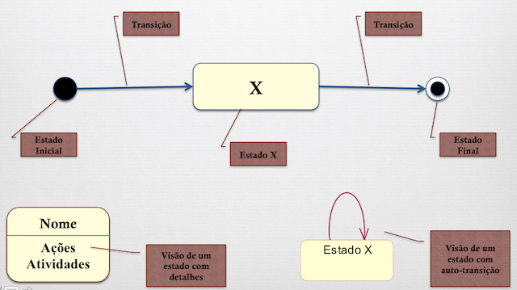

Fonte: Autoria própria

### 1.4. Diagrama de Máquina de Estados

- Um **Estado** representa uma situação ou condição na qual um objeto pode se encontrar ao longo da sua existência no sistema.
- O **Estado de um objeto** muda ao longo do tempo.
- Diagramas de Estado possuem um **único Estado Inicial e um ou mais Estados Finais**.
- Estados iniciais e finais são na realidade pseudo-estados.

**Figura 2: Representação de um Diagrama de Máquina de Estados - Lâmpada**

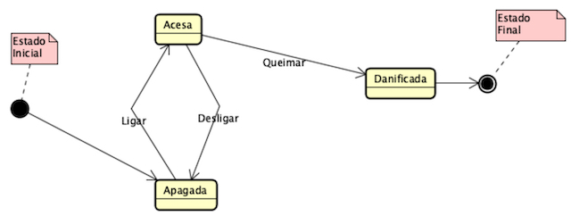

Fonte: Autoria própria

### 1.4.1. Cada Estado é composto por:

- **Nome**: uma string que distingue o estado de outros estados. Um estado sem nome designa- se “estado anônimo”.
- **Ações de entrada/saída**: ações executadas na entrada ou saída do estado, respectivamente. Transições internas: transições que ocorrem mas não causam a mudança do estado.
- **Sub-estados**: uma estrutura aninhada de um estado, envolvendo sub-estados disjuntos (seqüencialmente ativos) ou concorrentes (concorrentemente ativos).
- **Eventos adiados/deferidos**: uma lista de eventos que não são manipulados neste estado (corrente), mas, em vez disso, são adiados e colocados em fila para serem manipulados pelo objeto em outro estado.

### 1.5. Transições

- Uma transição é uma relação entre 2 estados.
- Um objeto que se encontra no primeiro estado realizará um conjunto de ações e mudará para o segundo estado quando ocorrer um determinado evento.
- São geradas por eventos.
- Escrita pela sintaxe:
  - Evento [condição] / ação

**Figura 3: Representação de Transição**

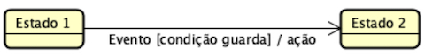

Fonte: Autoria própria

### 1.5.1. Cada Transição é composta por:

- **Estado de origem e de destino**: que a transição interliga.
- **Evento**: aciona a transição de estado, caso a condição de guarda seja satisfeita. Pode ser gerado por um ator externo ao sistema ou por um objeto do sistema.
- **Condição (ou condição de guarda)**: é uma expressão lógica que é avaliada quando a transição de estado deve ocorrer. Caso a condição não seja verdadeira, o evento é perdido.
- **Ações**: indica um método do objeto que deve ser executado quando a transição de estado se realizar.
- **Observações**: todas as partes de uma transição são opcionais.

### 2. Exemplos

### 2.1. Diagrama de Máquina de Estados de um Sistema de Matrícula

**Figura 4: Representação de um Diagrama de Máquina de Estados - Matrícula**

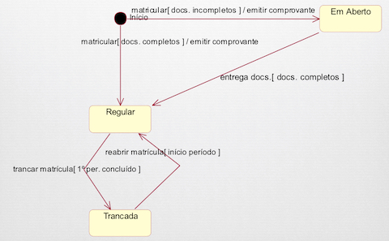

Fonte: Autoria própria

### 2.2. Diagrama de Máquina de Estados de um Sistema de Inscrição

**Figura 5: Representação de um Diagrama de Máquina de Estados - Inscrição**

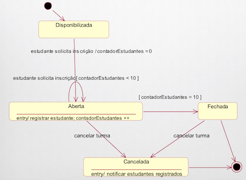

Fonte: Autoria própria

### 3. Resumo

- Mostram uma **visão dinâmica**.
- Ilustram os eventos e os estados interessantes de um objeto e o comportamento de um objeto em resposta a um evento.
- As transições são exibidas como flechas, rotuladas com seus eventos correspondentes.
- A notação utilizada é um retângulo arredondado.
- Incluir o pseudo-estado inicial que passa automaticamente para outro estado quando uma instância é criada.
- Exibem o ciclo de vida de um objeto.
  - Os **eventos** pelos quais ele passa.
  - As **transições e os estados** em que ele se encontra entre os eventos.
- Um objeto é considerado não modal (independente do estado) quando este objeto responde da mesma maneira a um evento.
- Utiliza-se 2 compartimentos para representação, onde o **superior é o nome do estado** e o **inferior são as ações internas** (métodos que deverão existir em uma determinada classe).
  - **Entry/função()** : ponto de entrada. Toda vez que entramos neste estado, esta operação será realizada. O método será executado na entrada deste estado.
  - **Exit/função()** : ponto de saída. Toda vez que sairmos do estado, esta operação, este método será executado.
  - **Do/função()** : é um tipo de ação que é executada durante o tempo de permanência naquele estado.

### Referências

- Esta aula foi elaborada a partir do conteúdo disponibilizado em cada um dos links indicados no próprio texto.
- GUEDES, G. T. A. UML 2 - **UMA ABORDAGEM PRÁTICA**. [S.L.]: NOVATEC, 2011.
- MEDEIROS, Ernani - **Desenvolvendo Software com UML 2.0 Definitivo** - Editora Pearson Makron Books.
- BOOCH, Grady; RUMBAUGH, James; JACOBSON, Ivar - **UML Guia do Usuário** - 2a. Edição - Editora Campus (Elsevier).

### Perguntas

- Esclareça suas eventuais dúvidas durante as aulas.
- Ou pelo *E-mail*: paulagiancoli@ifsp.edu.br.
- Ou acesse [Github Ana Giancoli](https://anagiancoli.github.io) e solicite atendimento para o componente curricular.
- Ou pelo *Fórum* do componente curricular.

*ADS - AOO - 3o. módulo*.  
Modelo e formato elaborado por profa. Ana Paula Müller Giancoli - BSD 2-Clause License. - Setembro.2020.